# Hospitalizations - EPI1 Scenarios

Pragati Prasad

2021-04-21

## Mean, Cumulative with 95% CI, and Averted per 100K

### Scenario HP01

Base Scenario: R0 1.4 and “2009-like” severity

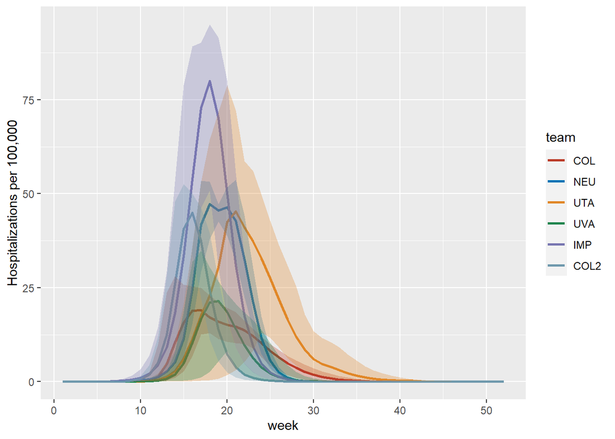

```r
library(ggsci)
library(reshape)
library(dplyr)
library(gridExtra)
library(ggplot2)
library(egg)
library(plyr)
library(tidyr)
library(knitr)
library(kableExtra)

path <- "../model-forecasts/"

team.folder <- c("Columbia/COL/EPI1/", "Northeastern/EPI1/", "UTAustin/", "UVirginia/", "Imperial/", "Columbia/COL2/EPI1/")
team.abbrev <- c("COL", "NEU", "UTA", "UVA", "IMP", "COL2")
file.types <-c("SymIllness", "Hosp", "Deaths", "AntiviralTX")
scn = "HP01_"
read_overall_mean <- function(scn){

  cols <- c("sm.mean", "sm.perc2p5", "sm.perc97p5")

  s <- read.csv(paste0(path,team.folder[1],scn,file.types[2],"_",team.abbrev[1],".csv"))
  hosp <- data.frame(c(s[which(s$Agegroup == "Overall" &
                                       s$Bin %in% cols),],
                             `team` = team.abbrev[1]))

  for(i in 2:6){

    if(i == 4){
      scn = gsub("HP", "HP_", scn)
    }
    if(i == 5){
      scn = gsub("_", "", scn)
    }
    if(i == 6){
      scn = paste0(scn, "_")
    }
    f = paste0(path,team.folder[i],scn,file.types[2],"_",team.abbrev[i],".csv")
    if(i == 5){
      f =  paste0(path,team.folder[i],scn,file.types[2],team.abbrev[i],".csv")
    }
    if(file.exists(f)){
      s <- read.csv(f)
      if(ncol(s) > 59){
        s <- s[-1]
      }
      if(i == 4){
        s <- s[which(s$Location == "US National"),]
      }
      hosp <- rbind.fill(hosp,
                               data.frame(c(s[which(s$Agegroup == "Overall" &
                                                      s$Bin %in% cols),],`team` = team.abbrev[i])))
    }

  }
  weeks <- paste0("Week",1:52)
  hosp$Cml[which(is.na(hosp$Cml))] <- hosp$cml[which(is.na(hosp$Cml))]
  cml <<- hosp[c("Cml", "team", "Bin")]

  long <- gather(hosp, week, illnesses, weeks, factor_key=TRUE)
  long$week <- as.integer(gsub("Week", "", long$week))

  cols <- c("Bin", "team", "week", "illnesses")
  long <- long[cols]
  long_wide <- spread(long, Bin, illnesses)

  return(long_wide)
}

long_HP01 <- read_overall_mean(scn = "HP01_")

ggplot(data = long_HP01, aes(x = week, y = sm.mean, group = team)) +
  geom_line(aes(color = team), lwd = 1.0) +
  geom_ribbon(aes(ymin = sm.perc2p5, ymax = sm.perc97p5, fill = team), alpha = 0.3,
              show.legend = FALSE)+
  ylab("Hospitalizations per 100,000") +
  scale_color_nejm() +
  scale_fill_nejm()
```

```r
table <- cml[which(cml$Bin == "sm.mean"),]
table <- table[,-3]

table$lower <-  cml$Cml[which(cml$Bin == "sm.perc2p5")]
table$upper <-  cml$Cml[which(cml$Bin == "sm.perc97p5")]
table$Team <- table$team
table$`Cum. Hospitalizations per 100K` <- table$Cml
table$`95% CI` <- paste0("(", round(table$lower, 2), ", ", round(table$upper, 2), ")")

rownames(table) <- NULL

knitr::kable(table[5:7], digits = 2, caption = "HP01, No Intervention", align=rep('c', 3)) %>%
  kable_styling(bootstrap_options = c("striped", "hover"))
```

HP01, No Intervention

| Team | Cum. Hospitalizations per 100K | 95% CI |
| --- | --- | --- |
| COL | 200.91 | (150.64, 256.15) |
| NEU | 345.49 | (343.87, 350.5) |
| UTA | 404.30 | (207.35, 531.88) |
| UVA | 135.52 | (109.76, 157.19) |
| IMP | 463.44 | (436.99, 491.38) |
| COL2 | 222.58 | (210.59, 234) |

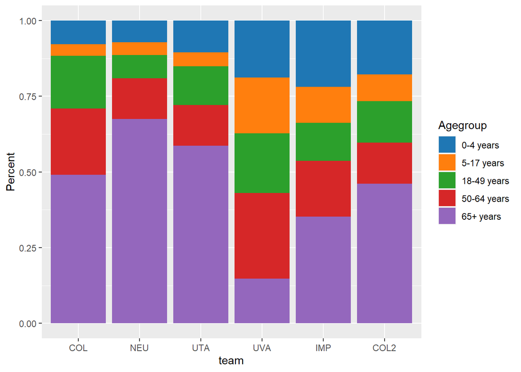

```r
table1 <- table


team.folder <- c("Columbia/COL/EPI1/", "Northeastern/EPI1/", "UTAustin/", "UVirginia/", "Imperial/", "Columbia/COL2/EPI1/")
team.abbrev <- c("COL", "NEU", "UTA", "UVA", "IMP", "COL2")
file.types <-c("SymIllness", "Hosp", "Deaths", "AntiviralTX")
scn = "HP01_"

read_ages <- function(scn){

  cols <- c("sm.mean", "sm.perc2p5", "sm.perc97p5")

  s <- read.csv(paste0(path,team.folder[1],scn,file.types[2],"_",team.abbrev[1],".csv"))
  hosp <- data.frame(c(s[which(s$Agegroup != "Overall" &
                                       s$Bin %in% cols),],
                             `team` = team.abbrev[1]))

  for(i in 2:6){

    if(i == 4){
      scn = gsub("HP", "HP_", scn)
    }
    if(i == 5){
      scn = gsub("_", "", scn)
    }
    if(i == 6){
      scn = paste0(scn, "_")
    }
    f = paste0(path,team.folder[i],scn,file.types[2],"_",team.abbrev[i],".csv")
    if(i == 5){
      f =  paste0(path,team.folder[i],scn,file.types[2],team.abbrev[i],".csv")
    }
    if(file.exists(f)){
      s <- read.csv(f)
      if(ncol(s) > 58){
        s <- s[-1]
      }
      hosp <- rbind.fill(hosp,
                               data.frame(c(s[which(s$Agegroup != "Overall" &
                                                      s$Bin %in% cols),],`team` = team.abbrev[i])))
    }

  }
  weeks <- paste0("Week",1:52)
  hosp$Cml[which(is.na(hosp$Cml))] <- hosp$cml[which(is.na(hosp$Cml))]
  cml <- hosp[c("Cml", "team", "Bin", "Agegroup")]
  cml$Agegroup <- sub("yr", "years", cml$Agegroup)
  cml$Agegroup <- factor(x = cml$Agegroup, levels = c("0-4 years", "5-17 years", "18-49 years", "50-64 years", "65+ years"))

  return(cml)
}

ages_1 <- read_ages(scn = "HP01_")
ggplot(ages_1, aes(fill=Agegroup, y=Cml, x=team)) +
  geom_bar(position="fill", stat="identity") +
  ylab("Percent")+
  scale_fill_d3()
```

```r
scenario="HP01_"
averted_age <- data.frame(scenario = scenario,
                          team = ages_1$team[which(ages_1$Bin == "sm.mean")],
                          agegroup = ages_1$Agegroup[which(ages_1$Bin == "sm.mean")],
                          cml = ages_1$Cml[which(ages_1$Bin == "sm.mean")],
                          lower = ages_1$Cml[which(ages_1$Bin == "sm.perc2p5")],
                          upper = ages_1$Cml[which(ages_1$Bin == "sm.perc97p5")])
write.csv(averted_age, "Hospitalizations_EPI1_HP01.csv")
```

### HP02

VX1

“Early”: Vaccine available 100 days after September 1

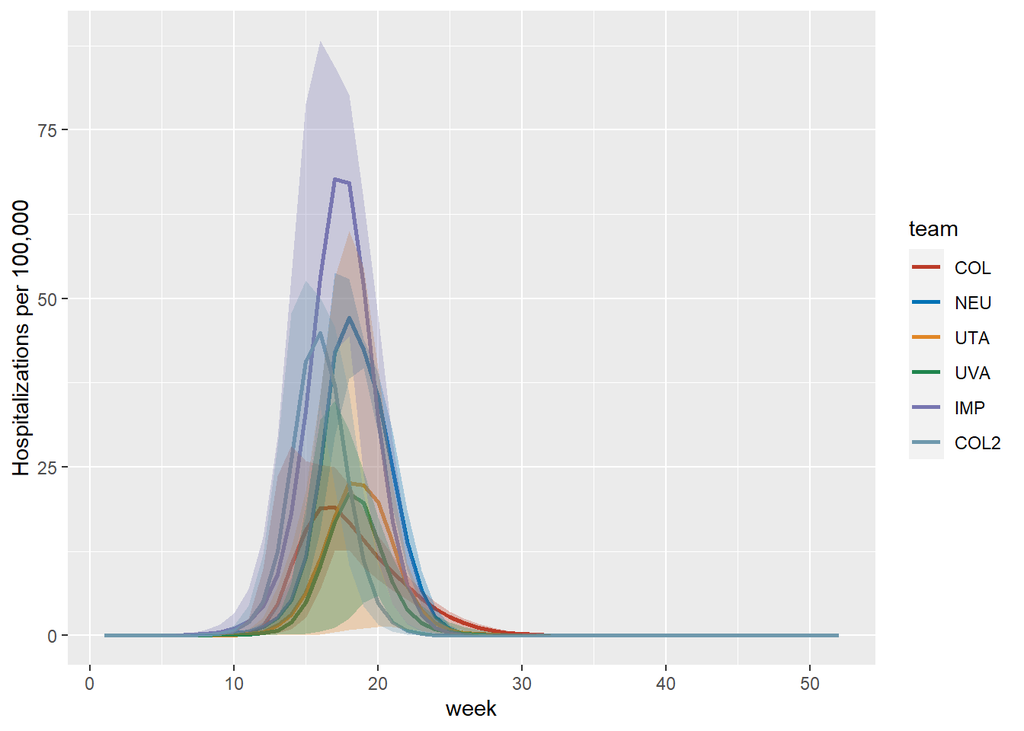

```r
scenario <- "HP02_"

long <- read_overall_mean(scn = scenario)

ggplot(data = long, aes(x = week, y = sm.mean, group = team)) +
  geom_line(aes(color = team), lwd = 1.0) +
  geom_ribbon(aes(ymin = sm.perc2p5, ymax = sm.perc97p5, fill = team), alpha = 0.3,
              show.legend = FALSE)+
  ylab("Hospitalizations per 100,000") +
  scale_color_nejm() +
  scale_fill_nejm()
```

```r
table <- cml[which(cml$Bin == "sm.mean"),]
table <- table[,-3]

table$lower <-  cml$Cml[which(cml$Bin == "sm.perc2p5")]
table$upper <-  cml$Cml[which(cml$Bin == "sm.perc97p5")]
table$Team <- table$team
table$`Cum. Hospitalizations per 100K` <- table$Cml
table$`95% CI` <- paste0("(", round(table$lower, 2), ", ", round(table$upper, 2), ")")

table$`Averted Hospitalizations per 100K (HP01)` <- ifelse(table$Team %in% table1$Team, table1$`Cum. Hospitalizations per 100K` - table$`Cum. Hospitalizations per 100K`, NA)
table$`% Reduction in Burden (HP01)` <- ifelse(table$Team %in% table1$Team, 100 * (table1$`Cum. Hospitalizations per 100K` - table$`Cum. Hospitalizations per 100K`) / table1$`Cum. Hospitalizations per 100K`, NA)

rownames(table) <- NULL

knitr::kable(table[5:9], digits = 2, caption = "HP02: Compared to HP01", align=rep('c', 4)) %>%
  kable_styling(bootstrap_options = c("striped", "hover"))
```

HP02: Compared to HP01

| Team | Cum. Hospitalizations per 100K | 95% CI | Averted Hospitalizations per 100K (HP01) | % Reduction in Burden (HP01) |
| --- | --- | --- | --- | --- |
| COL | 146.60 | (90.56, 220.27) | 54.31 | 27.03 |
| NEU | 263.36 | (256.6, 283.28) | 82.13 | 23.77 |
| UTA | 134.05 | (7.95, 317.96) | 270.24 | 66.84 |
| UVA | 105.79 | (45.16, 149.57) | 29.73 | 21.94 |
| IMP | 370.38 | (300.69, 437.73) | 93.06 | 20.08 |
| COL2 | 210.41 | (186.86, 226.79) | 12.18 | 5.47 |

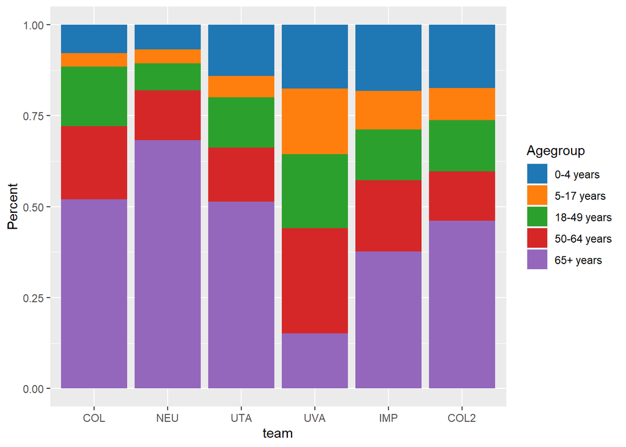

```r
#Bar chart for ages
ages <- read_ages(scn = scenario)
ggplot(ages, aes(fill=Agegroup, y=Cml, x=team)) +
  geom_bar(position="fill", stat="identity") +
  ylab("Percent")+
  scale_fill_d3()
```

```r
averted <- data.frame(scenario = rep(scenario, nrow(table)),
                                     team = table$Team,
                                     reduction = table$`% Reduction in Burden (HP01)`)
averted_age <- data.frame(scenario = scenario,
                          team = ages$team[which(ages$Bin == "sm.mean")],
                          agegroup = ages$Agegroup[which(ages$Bin == "sm.mean")],
                          reduction = 100*(ages_1$Cml[which(ages_1$Bin == "sm.mean")] -
                                       ages$Cml[which(ages$Bin == "sm.mean")]) /
                            ages_1$Cml[which(ages_1$Bin == "sm.mean")])
```

### HP03

VX2

“Normal”: Vaccine available 150 days after September 1

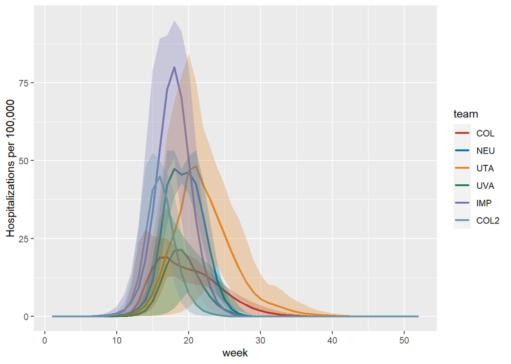

```r
scenario <- "HP03_"

long <- read_overall_mean(scn = scenario)

ggplot(data = long, aes(x = week, y = sm.mean, group = team)) +
  geom_line(aes(color = team), lwd = 1.0) +
  geom_ribbon(aes(ymin = sm.perc2p5, ymax = sm.perc97p5, fill = team), alpha = 0.3,
              show.legend = FALSE)+
  ylab("Hospitalizations per 100,000") +
  scale_color_nejm() +
  scale_fill_nejm()
```

```r
table <- cml[which(cml$Bin == "sm.mean"),]
table <- table[,-3]

table$lower <-  cml$Cml[which(cml$Bin == "sm.perc2p5")]
table$upper <-  cml$Cml[which(cml$Bin == "sm.perc97p5")]
table$Team <- table$team
table$`Cum. Hospitalizations per 100K` <- table$Cml
table$`95% CI` <- paste0("(", round(table$lower, 2), ", ", round(table$upper, 2), ")")

table$`Averted Hospitalizations per 100K (HP01)` <- ifelse(table$Team %in% table1$Team, table1$`Cum. Hospitalizations per 100K` - table$`Cum. Hospitalizations per 100K`, NA)
table$`% Reduction in Burden (HP01)` <- ifelse(table$Team %in% table1$Team, 100 * (table1$`Cum. Hospitalizations per 100K` - table$`Cum. Hospitalizations per 100K`) / table1$`Cum. Hospitalizations per 100K`, NA)

rownames(table) <- NULL

knitr::kable(table[5:9], digits = 2, caption = "HP03: Compared to HP01", align=rep('c', 4)) %>%
  kable_styling(bootstrap_options = c("striped", "hover"))
```

HP03: Compared to HP01

| Team | Cum. Hospitalizations per 100K | 95% CI | Averted Hospitalizations per 100K (HP01) | % Reduction in Burden (HP01) |
| --- | --- | --- | --- | --- |
| COL | 200.91 | (150.64, 256.15) | 0.00 | 0.00 |
| NEU | 344.81 | (343.23, 349.36) | 0.68 | 0.20 |
| UTA | 420.80 | (226.26, 546.17) | -16.50 | -4.08 |
| UVA | 134.65 | (104.17, 157.17) | 0.86 | 0.64 |
| IMP | 462.03 | (435.22, 490.04) | 1.41 | 0.30 |
| COL2 | 222.50 | (210.43, 233.99) | 0.08 | 0.04 |

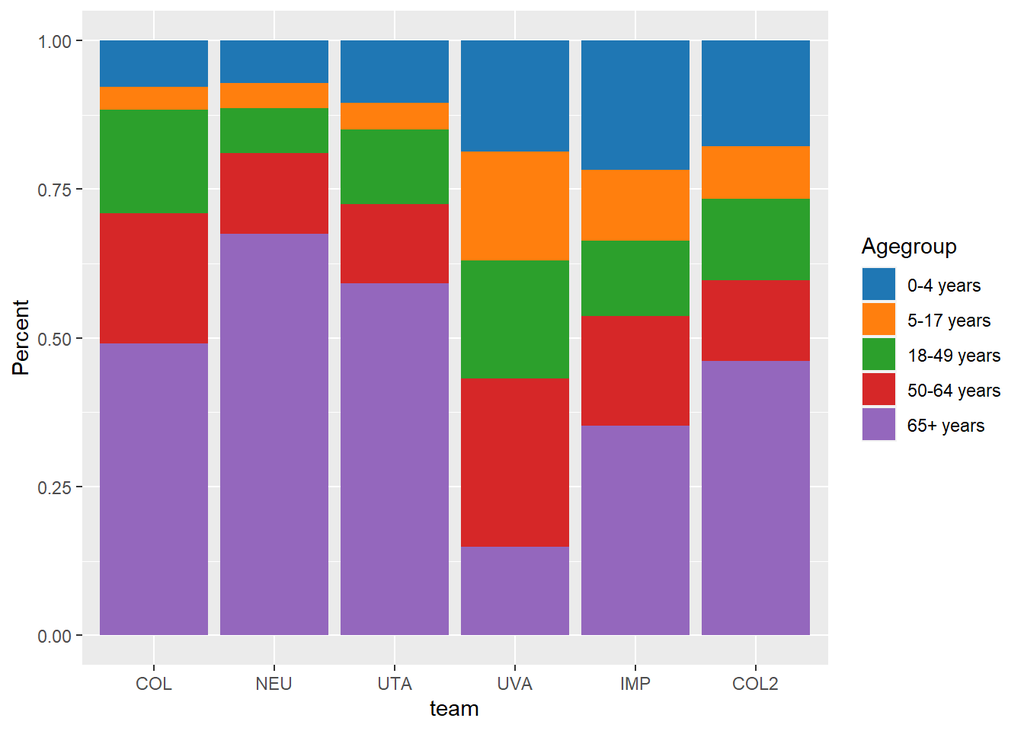

```r
#Bar chart for ages
ages <- read_ages(scn = scenario)
ggplot(ages, aes(fill=Agegroup, y=Cml, x=team)) +
  geom_bar(position="fill", stat="identity") +
  ylab("Percent")+
  scale_fill_d3()
```

```r
averted <- rbind(averted, data.frame(scenario = rep(scenario, nrow(table)),
                                     team = table$Team,
                                     reduction = table$`% Reduction in Burden (HP01)`))
averted_age <- rbind(averted_age,
                     data.frame(scenario = scenario,
                          team = ages$team[which(ages$Bin == "sm.mean")],
                          agegroup = ages$Agegroup[which(ages$Bin == "sm.mean")],
                          reduction = 100*(ages_1$Cml[which(ages_1$Bin == "sm.mean")] -
                                       ages$Cml[which(ages$Bin == "sm.mean")]) /
                            ages_1$Cml[which(ages_1$Bin == "sm.mean")]))
```

### HP04

SC1

Weekly Symptomatic Prevalence > 1% trigger, early (VX1) vaccine availability reopening

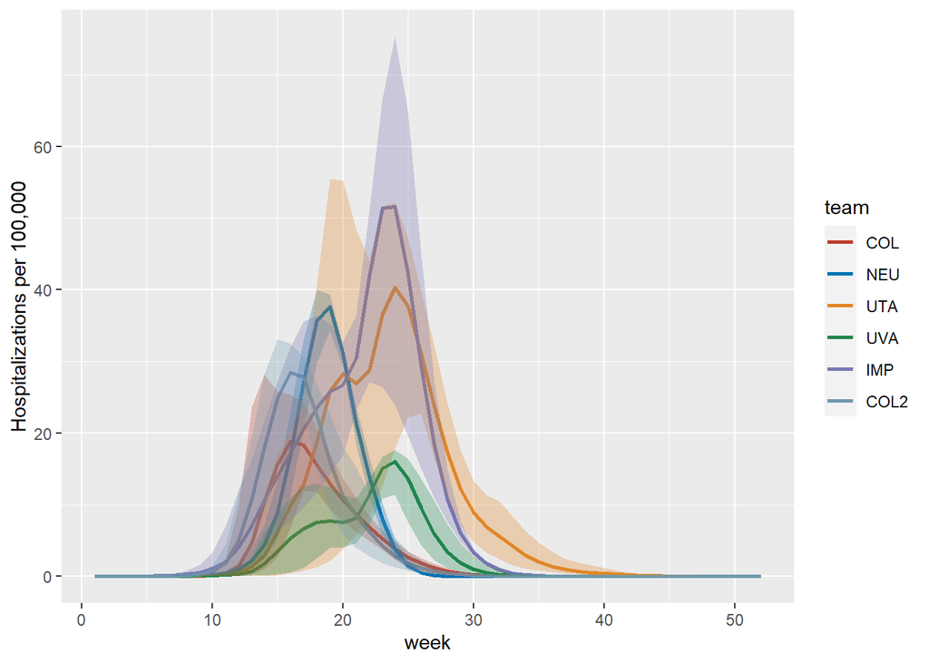

```r
scenario <- "HP04_"

long <- read_overall_mean(scn = scenario)

ggplot(data = long, aes(x = week, y = sm.mean, group = team, color = team)) +
  geom_line(aes(color = team), lwd = 1.0) +
  geom_ribbon(aes(ymin = sm.perc2p5, ymax = sm.perc97p5, fill = team),
              alpha = 0.3,
              linetype=0,
              show.legend = FALSE)+
  ylab("Hospitalizations per 100,000") +
  scale_color_nejm() +
  scale_fill_nejm()
```

```r
table <- cml[which(cml$Bin == "sm.mean"),]
table <- table[,-3]

table$lower <-  cml$Cml[which(cml$Bin == "sm.perc2p5")]
table$upper <-  cml$Cml[which(cml$Bin == "sm.perc97p5")]
table$Team <- table$team
table$`Cum. Hospitalizations per 100K` <- table$Cml
table$`95% CI` <- paste0("(", round(table$lower, 2), ", ", round(table$upper, 2), ")")

table$`Averted Hospitalizations per 100K (HP01)` <- ifelse(table$Team %in% table1$Team, table1$`Cum. Hospitalizations per 100K` - table$`Cum. Hospitalizations per 100K`, NA)
table$`% Reduction in Burden (HP01)` <- ifelse(table$Team %in% table1$Team, 100 * (table1$`Cum. Hospitalizations per 100K` - table$`Cum. Hospitalizations per 100K`) / table1$`Cum. Hospitalizations per 100K`, NA)

rownames(table) <- NULL

knitr::kable(table[5:9], digits = 2, caption = "HP04: Compared to HP01", align=rep('c', 4)) %>%
  kable_styling(bootstrap_options = c("striped", "hover"))
```

HP04: Compared to HP01

| Team | Cum. Hospitalizations per 100K | 95% CI | Averted Hospitalizations per 100K (HP01) | % Reduction in Burden (HP01) |
| --- | --- | --- | --- | --- |
| COL | 141.24 | (84.65, 213.18) | 59.67 | 29.70 |
| NEU | 215.22 | (209.72, 231.09) | 130.27 | 37.71 |
| UTA | 397.14 | (209.69, 515.19) | 7.16 | 1.77 |
| UVA | 128.76 | (107.54, 145.24) | 6.76 | 4.99 |
| IMP | 442.78 | (419.65, 476.02) | 20.66 | 4.46 |
| COL2 | 194.28 | (183.47, 205.15) | 28.30 | 12.72 |

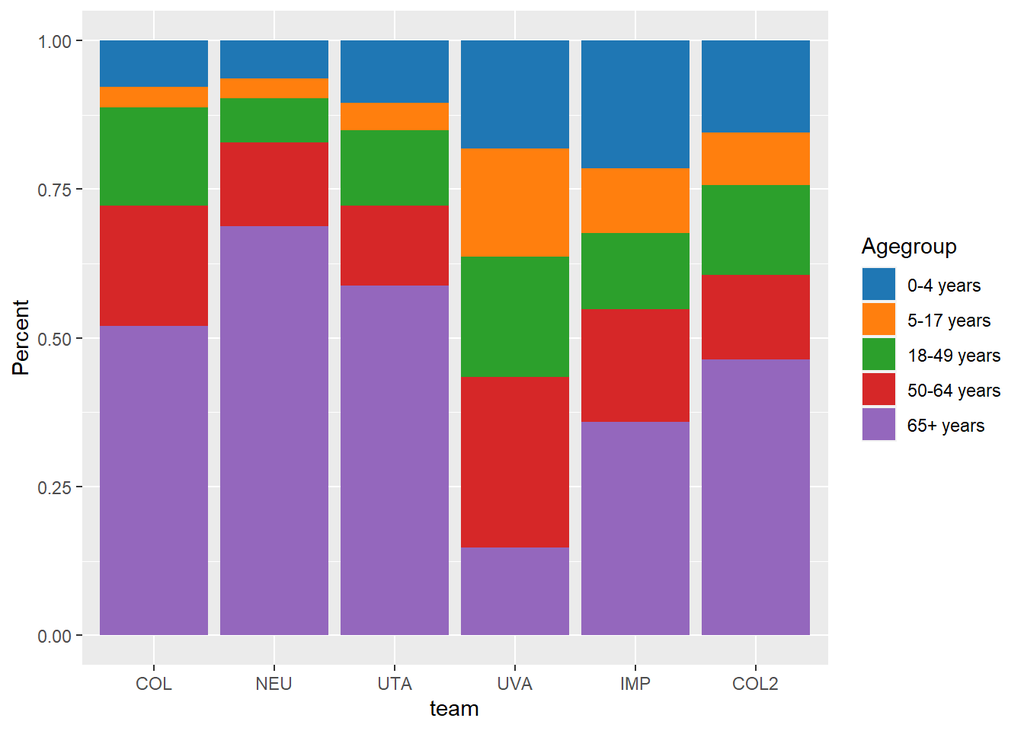

```r
#Bar chart for ages
ages <- read_ages(scn = scenario)
ggplot(ages, aes(fill=Agegroup, y=Cml, x=team)) +
  geom_bar(position="fill", stat="identity") +
  ylab("Percent")+
  scale_fill_d3()
```

```r
averted <- rbind(averted, data.frame(scenario = rep(scenario, nrow(table)),
                                     team = table$Team,
                                     reduction = table$`% Reduction in Burden (HP01)`))
averted_age <- rbind(averted_age,
                     data.frame(scenario = scenario,
                          team = ages$team[which(ages$Bin == "sm.mean")],
                          agegroup = ages$Agegroup[which(ages$Bin == "sm.mean")],
                          reduction = 100*(ages_1$Cml[which(ages_1$Bin == "sm.mean")] -
                                       ages$Cml[which(ages$Bin == "sm.mean")]) /
                            ages_1$Cml[which(ages_1$Bin == "sm.mean")]))
```

### HP05

SC2

Close on October 28, early (VX1) vaccine availability reopening

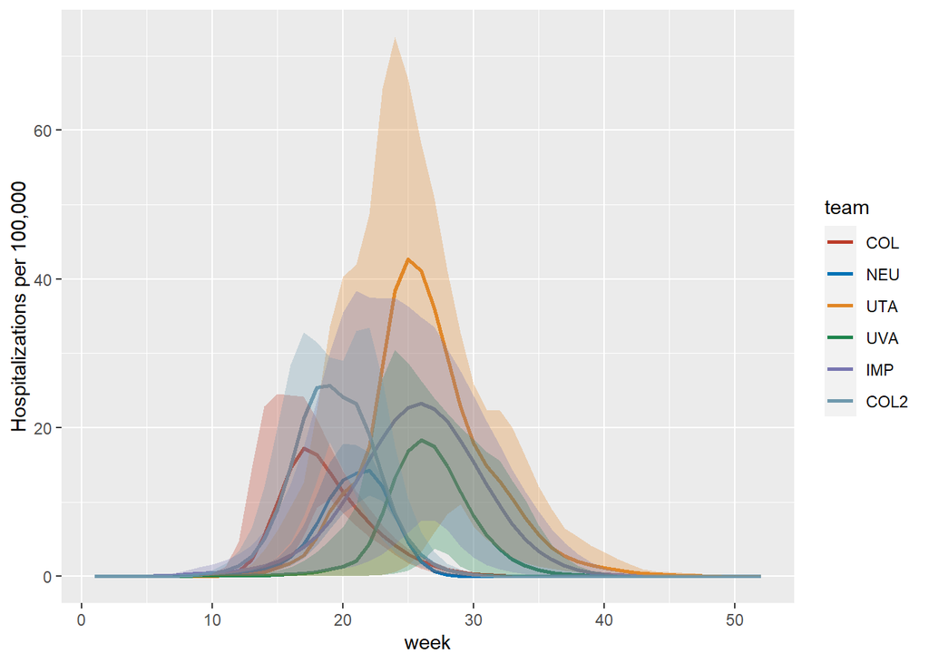

```r
scenario <- "HP05_"

long <- read_overall_mean(scn = scenario)

ggplot(data = long, aes(x = week, y = sm.mean, group = team)) +
  geom_line(aes(color = team), lwd = 1.0) +
  geom_ribbon(aes(ymin = sm.perc2p5, ymax = sm.perc97p5, fill = team), alpha = 0.3,
              show.legend = FALSE)+
  ylab("Hospitalizations per 100,000") +
  scale_color_nejm() +
  scale_fill_nejm()
```

```r
table <- cml[which(cml$Bin == "sm.mean"),]
table <- table[,-3]

table$lower <-  cml$Cml[which(cml$Bin == "sm.perc2p5")]
table$upper <-  cml$Cml[which(cml$Bin == "sm.perc97p5")]
table$Team <- table$team
table$`Cum. Hospitalizations per 100K` <- table$Cml
table$`95% CI` <- paste0("(", round(table$lower, 2), ", ", round(table$upper, 2), ")")

table$`Averted Hospitalizations per 100K (HP01)` <- ifelse(table$Team %in% table1$Team, table1$`Cum. Hospitalizations per 100K` - table$`Cum. Hospitalizations per 100K`, NA)
table$`% Reduction in Burden (HP01)` <- ifelse(table$Team %in% table1$Team, 100 * (table1$`Cum. Hospitalizations per 100K` - table$`Cum. Hospitalizations per 100K`) / table1$`Cum. Hospitalizations per 100K`, NA)

rownames(table) <- NULL

knitr::kable(table[5:9], digits = 2, caption = "HP05: Compared to HP01", align=rep('c', 4)) %>%
  kable_styling(bootstrap_options = c("striped", "hover"))
```

HP05: Compared to HP01

| Team | Cum. Hospitalizations per 100K | 95% CI | Averted Hospitalizations per 100K (HP01) | % Reduction in Burden (HP01) |
| --- | --- | --- | --- | --- |
| COL | 126.65 | (70.03, 195.67) | 74.26 | 36.96 |
| NEU | 98.13 | (88.69, 124.37) | 247.35 | 71.60 |
| UTA | 383.99 | (151.74, 529.4) | 20.30 | 5.02 |
| UVA | 134.92 | (109.63, 155.18) | 0.59 | 0.44 |
| IMP | 270.98 | (163.62, 347.48) | 192.47 | 41.53 |
| COL2 | 206.67 | (196.27, 217.46) | 15.91 | 7.15 |

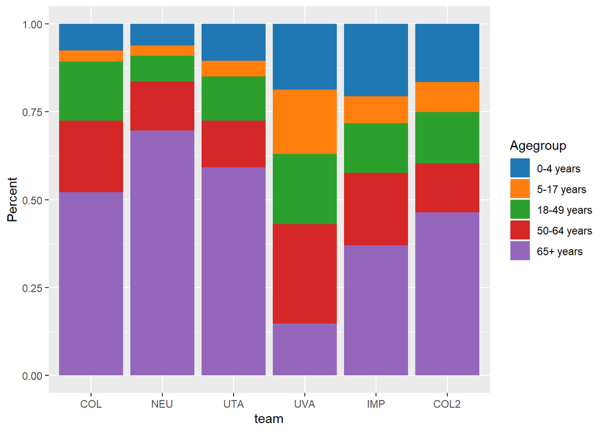

```r
#Bar chart for ages
ages <- read_ages(scn = scenario)
ggplot(ages, aes(fill=Agegroup, y=Cml, x=team)) +
  geom_bar(position="fill", stat="identity") +
  ylab("Percent")+
  scale_fill_d3()
```

```r
averted <- rbind(averted, data.frame(scenario = rep(scenario, nrow(table)),
                                     team = table$Team,
                                     reduction = table$`% Reduction in Burden (HP01)`))
averted_age <- rbind(averted_age,
                     data.frame(scenario = scenario,
                          team = ages$team[which(ages$Bin == "sm.mean")],
                          agegroup = ages$Agegroup[which(ages$Bin == "sm.mean")],
                          reduction = 100*(ages_1$Cml[which(ages_1$Bin == "sm.mean")] -
                                       ages$Cml[which(ages$Bin == "sm.mean")]) /
                            ages_1$Cml[which(ages_1$Bin == "sm.mean")]))
```

### HP06

SC3

Weekly Symptomatic Prevalence > 1% trigger, normal (VX2) vaccine availability reopening

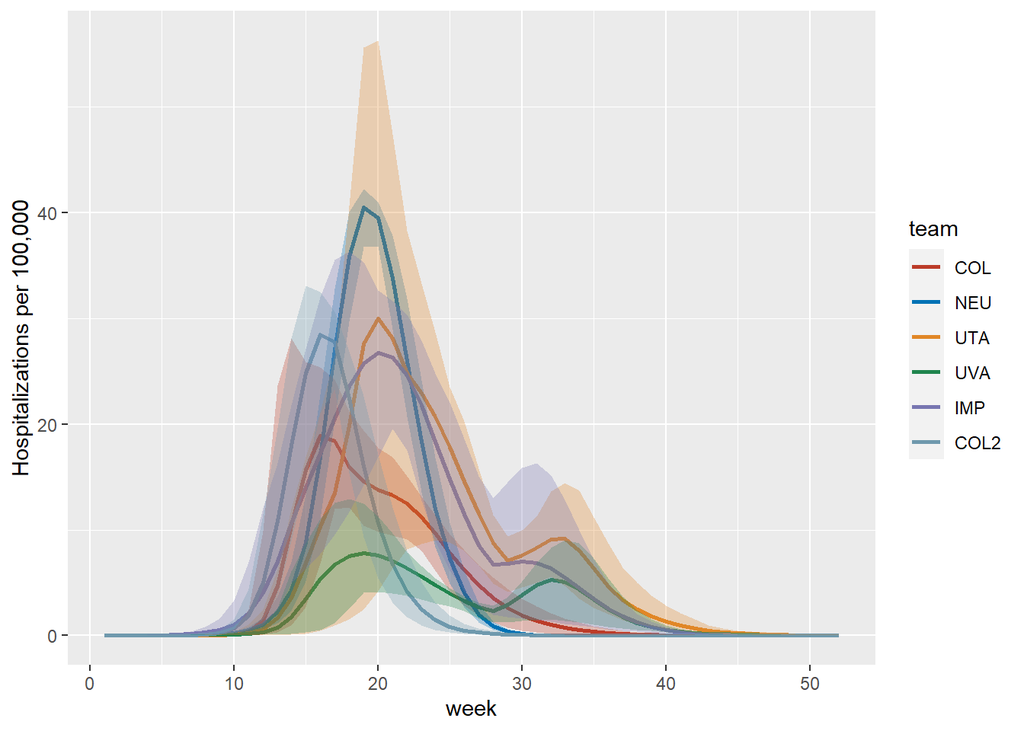

```r
scenario <- "HP06_"

long <- read_overall_mean(scn = scenario)

ggplot(data = long, aes(x = week, y = sm.mean, group = team)) +
  geom_line(aes(color = team), lwd = 1.0) +
  geom_ribbon(aes(ymin = sm.perc2p5, ymax = sm.perc97p5, fill = team), alpha = 0.3,
              show.legend = FALSE)+
  ylab("Hospitalizations per 100,000") +
  scale_color_nejm() +
  scale_fill_nejm()
```

```r
table <- cml[which(cml$Bin == "sm.mean"),]
table <- table[,-3]

table$lower <-  cml$Cml[which(cml$Bin == "sm.perc2p5")]
table$upper <-  cml$Cml[which(cml$Bin == "sm.perc97p5")]
table$Team <- table$team
table$`Cum. Hospitalizations per 100K` <- table$Cml
table$`95% CI` <- paste0("(", round(table$lower, 2), ", ", round(table$upper, 2), ")")

table$`Averted Hospitalizations per 100K (HP01)` <- ifelse(table$Team %in% table1$Team, table1$`Cum. Hospitalizations per 100K` - table$`Cum. Hospitalizations per 100K`, NA)
table$`% Reduction in Burden (HP01)` <- ifelse(table$Team %in% table1$Team, 100 * (table1$`Cum. Hospitalizations per 100K` - table$`Cum. Hospitalizations per 100K`) / table1$`Cum. Hospitalizations per 100K`, NA)

rownames(table) <- NULL

knitr::kable(table[5:9], digits = 2, caption = "HP06: Compared to HP01", align=rep('c', 4)) %>%
  kable_styling(bootstrap_options = c("striped", "hover"))
```

HP06: Compared to HP01

| Team | Cum. Hospitalizations per 100K | 95% CI | Averted Hospitalizations per 100K (HP01) | % Reduction in Burden (HP01) |
| --- | --- | --- | --- | --- |
| COL | 192.60 | (143.25, 248.24) | 8.31 | 4.14 |
| NEU | 282.24 | (281.86, 283.39) | 63.25 | 18.31 |
| UTA | 336.00 | (141.12, 464.54) | 68.30 | 16.89 |
| UVA | 115.66 | (99.38, 129.74) | 19.85 | 14.65 |
| IMP | 334.85 | (307.52, 357.53) | 128.59 | 27.75 |
| COL2 | 184.02 | (171.47, 196.09) | 38.56 | 17.33 |

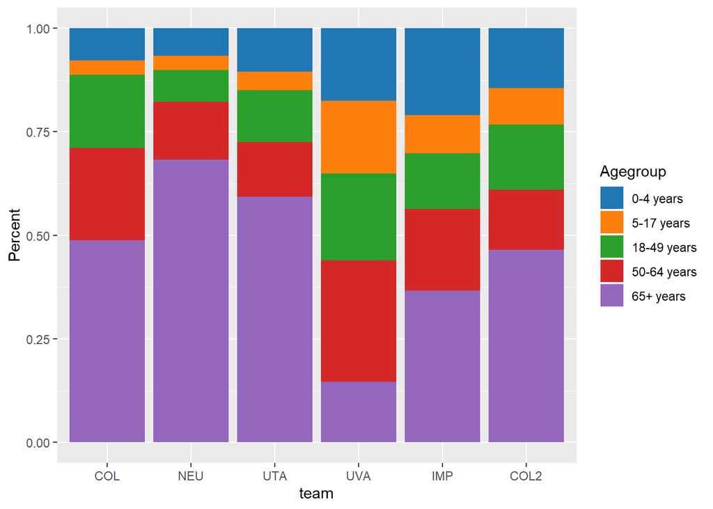

```r
#Bar chart for ages
ages <- read_ages(scn = scenario)
ggplot(ages, aes(fill=Agegroup, y=Cml, x=team)) +
  geom_bar(position="fill", stat="identity") +
  ylab("Percent")+
  scale_fill_d3()
```

```r
averted <- rbind(averted, data.frame(scenario = rep(scenario, nrow(table)),
                                     team = table$Team,
                                     reduction = table$`% Reduction in Burden (HP01)`))
averted_age <- rbind(averted_age,
                     data.frame(scenario = scenario,
                          team = ages$team[which(ages$Bin == "sm.mean")],
                          agegroup = ages$Agegroup[which(ages$Bin == "sm.mean")],
                          reduction = 100*(ages_1$Cml[which(ages_1$Bin == "sm.mean")] -
                                       ages$Cml[which(ages$Bin == "sm.mean")]) /
                            ages_1$Cml[which(ages_1$Bin == "sm.mean")]))
```

### HP07

SC4

Close on October 28, normal (VX2) vaccine availability reopening

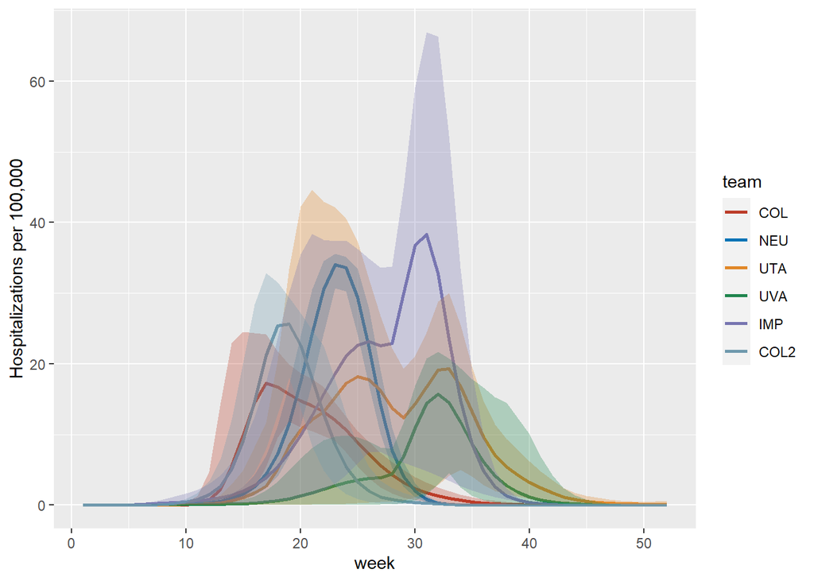

```r
scenario <- "HP07_"

long <- read_overall_mean(scn = scenario)

ggplot(data = long, aes(x = week, y = sm.mean, group = team)) +
  geom_line(aes(color = team), lwd = 1.0) +
  geom_ribbon(aes(ymin = sm.perc2p5, ymax = sm.perc97p5, fill = team), alpha = 0.3,
              show.legend = FALSE)+
  ylab("Hospitalizations per 100,000") +
  scale_color_nejm() +
  scale_fill_nejm()
```

```r
table <- cml[which(cml$Bin == "sm.mean"),]
table <- table[,-3]

table$lower <-  cml$Cml[which(cml$Bin == "sm.perc2p5")]
table$upper <-  cml$Cml[which(cml$Bin == "sm.perc97p5")]
table$Team <- table$team
table$`Cum. Hospitalizations per 100K` <- table$Cml
table$`95% CI` <- paste0("(", round(table$lower, 2), ", ", round(table$upper, 2), ")")

table$`Averted Hospitalizations per 100K (HP01)` <- ifelse(table$Team %in% table1$Team, table1$`Cum. Hospitalizations per 100K` - table$`Cum. Hospitalizations per 100K`, NA)
table$`% Reduction in Burden (HP01)` <- ifelse(table$Team %in% table1$Team, 100 * (table1$`Cum. Hospitalizations per 100K` - table$`Cum. Hospitalizations per 100K`) / table1$`Cum. Hospitalizations per 100K`, NA)

rownames(table) <- NULL

knitr::kable(table[5:9], digits = 2, caption = "HP07: Compared to HP01", align=rep('c', 4)) %>%
  kable_styling(bootstrap_options = c("striped", "hover"))
```

HP07: Compared to HP01

| Team | Cum. Hospitalizations per 100K | 95% CI | Averted Hospitalizations per 100K (HP01) | % Reduction in Burden (HP01) |
| --- | --- | --- | --- | --- |
| COL | 185.39 | (135.42, 240.39) | 15.52 | 7.73 |
| NEU | 251.14 | (247.66, 260.49) | 94.35 | 27.31 |
| UTA | 304.38 | (65.56, 476.89) | 99.92 | 24.71 |
| UVA | 131.05 | (109.45, 142.05) | 4.47 | 3.30 |
| IMP | 391.40 | (364.23, 423.35) | 72.04 | 15.54 |
| COL2 | 183.36 | (170.43, 195.91) | 39.22 | 17.62 |

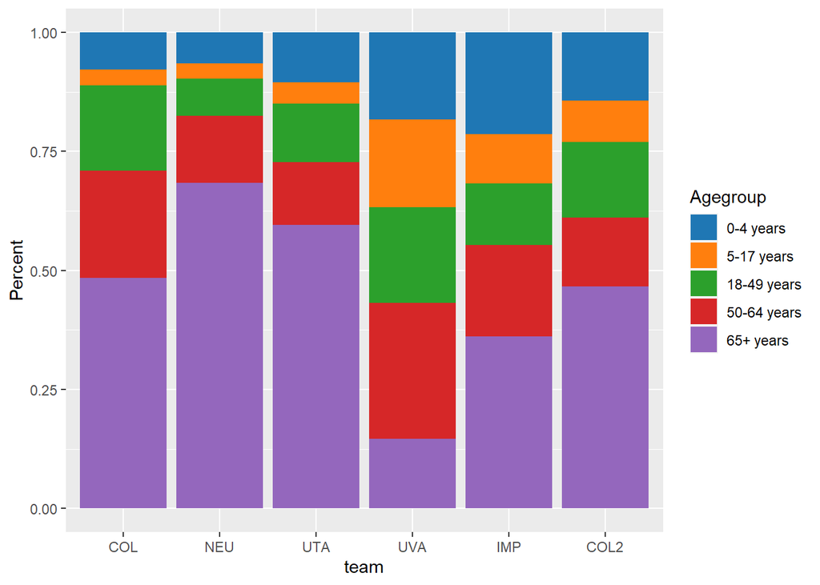

```r
#Bar chart for ages
ages <- read_ages(scn = scenario)
ggplot(ages, aes(fill=Agegroup, y=Cml, x=team)) +
  geom_bar(position="fill", stat="identity") +
  ylab("Percent")+
  scale_fill_d3()
```

```r
averted <- rbind(averted, data.frame(scenario = rep(scenario, nrow(table)),
                                     team = table$Team,
                                     reduction = table$`% Reduction in Burden (HP01)`))
averted_age <- rbind(averted_age,
                     data.frame(scenario = scenario,
                          team = ages$team[which(ages$Bin == "sm.mean")],
                          agegroup = ages$Agegroup[which(ages$Bin == "sm.mean")],
                          reduction = 100*(ages_1$Cml[which(ages_1$Bin == "sm.mean")] -
                                       ages$Cml[which(ages$Bin == "sm.mean")]) /
                            ages_1$Cml[which(ages_1$Bin == "sm.mean")]))
```

### HP08

AV

Antivirals

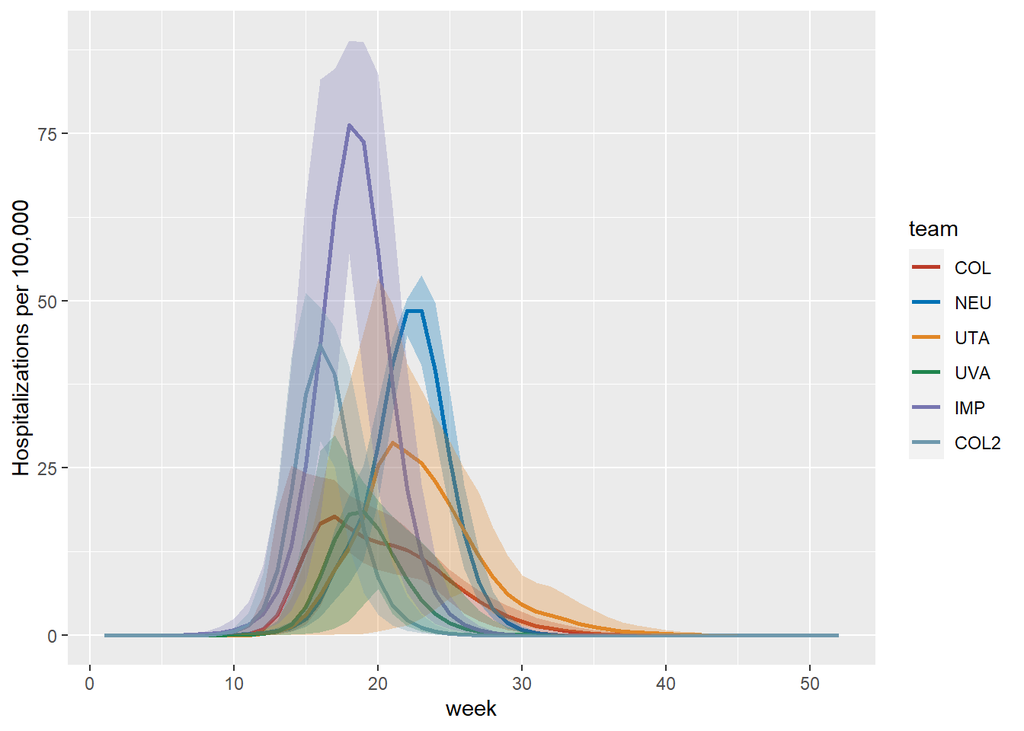

```r
scenario <- "HP08_"

long <- read_overall_mean(scn = scenario)

ggplot(data = long, aes(x = week, y = sm.mean, group = team)) +
  geom_line(aes(color = team), lwd = 1.0) +
  geom_ribbon(aes(ymin = sm.perc2p5, ymax = sm.perc97p5, fill = team), alpha = 0.3,
              show.legend = FALSE)+
  ylab("Hospitalizations per 100,000") +
  scale_color_nejm() +
  scale_fill_nejm()
```

```r
table <- cml[which(cml$Bin == "sm.mean"),]
table <- table[,-3]

table$lower <-  cml$Cml[which(cml$Bin == "sm.perc2p5")]
table$upper <-  cml$Cml[which(cml$Bin == "sm.perc97p5")]
table$Team <- table$team
table$`Cum. Hospitalizations per 100K` <- table$Cml
table$`95% CI` <- paste0("(", round(table$lower, 2), ", ", round(table$upper, 2), ")")

table$`Averted Hospitalizations per 100K (HP01)` <- ifelse(table$Team %in% table1$Team, table1$`Cum. Hospitalizations per 100K` - table$`Cum. Hospitalizations per 100K`, NA)
table$`% Reduction in Burden (HP01)` <- ifelse(table$Team %in% table1$Team, 100 * (table1$`Cum. Hospitalizations per 100K` - table$`Cum. Hospitalizations per 100K`) / table1$`Cum. Hospitalizations per 100K`, NA)

rownames(table) <- NULL

knitr::kable(table[5:9], digits = 2, caption = "HP08: Compared to HP01", align=rep('c', 4)) %>%
  kable_styling(bootstrap_options = c("striped", "hover"))
```

HP08: Compared to HP01

| Team | Cum. Hospitalizations per 100K | 95% CI | Averted Hospitalizations per 100K (HP01) | % Reduction in Burden (HP01) |
| --- | --- | --- | --- | --- |
| COL | 185.11 | (134.78, 240.71) | 15.81 | 7.87 |
| NEU | 314.86 | (314.16, 316.64) | 30.63 | 8.87 |
| UTA | 263.90 | (96.68, 354.25) | 140.40 | 34.73 |
| UVA | 116.52 | (94.44, 135.09) | 19.00 | 14.02 |
| IMP | 449.60 | (423.74, 477.43) | 13.84 | 2.99 |
| COL2 | 216.25 | (204.15, 227.58) | 6.34 | 2.85 |

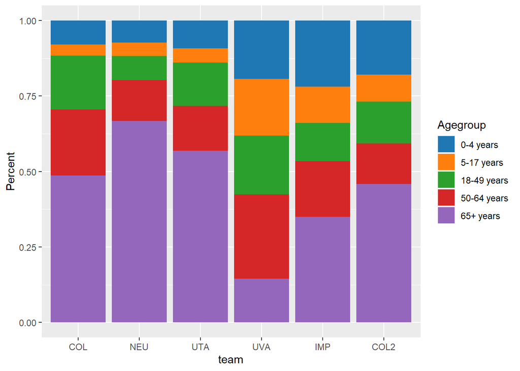

```r
#Bar chart for ages
ages <- read_ages(scn = scenario)
ggplot(ages, aes(fill=Agegroup, y=Cml, x=team)) +
  geom_bar(position="fill", stat="identity") +
  ylab("Percent")+
  scale_fill_d3()
```

```r
averted <- rbind(averted, data.frame(scenario = rep(scenario, nrow(table)),
                                     team = table$Team,
                                     reduction = table$`% Reduction in Burden (HP01)`))
averted_age <- rbind(averted_age,
                     data.frame(scenario = scenario,
                          team = ages$team[which(ages$Bin == "sm.mean")],
                          agegroup = ages$Agegroup[which(ages$Bin == "sm.mean")],
                          reduction = 100*(ages_1$Cml[which(ages_1$Bin == "sm.mean")] -
                                       ages$Cml[which(ages$Bin == "sm.mean")]) /
                            ages_1$Cml[which(ages_1$Bin == "sm.mean")]))
```

### HP09

VX1 & SC1 & AV

- “Early”: Vaccine available 100 days after September 1
- Weekly Symptomatic Prevalence > 1% trigger, early (VX1) vaccine availability reopening
- Antivirals

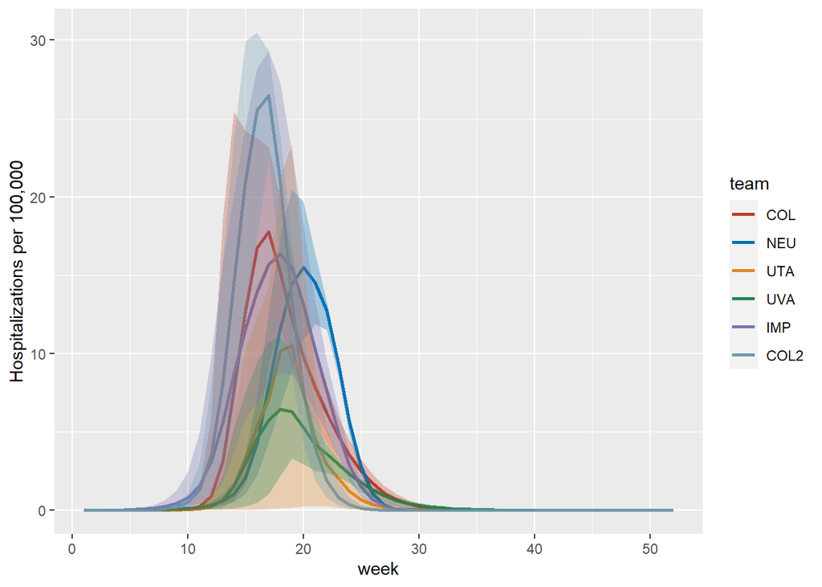

```r
scenario <- "HP09_"

long <- read_overall_mean(scn = scenario)

ggplot(data = long, aes(x = week, y = sm.mean, group = team)) +
  geom_line(aes(color = team), lwd = 1.0) +
  geom_ribbon(aes(ymin = sm.perc2p5, ymax = sm.perc97p5, fill = team), alpha = 0.3,
              show.legend = FALSE)+
  ylab("Hospitalizations per 100,000") +
  scale_color_nejm() +
  scale_fill_nejm()
```

```r
table <- cml[which(cml$Bin == "sm.mean"),]
table <- table[,-3]

table$lower <-  cml$Cml[which(cml$Bin == "sm.perc2p5")]
table$upper <-  cml$Cml[which(cml$Bin == "sm.perc97p5")]
table$Team <- table$team
table$`Cum. Hospitalizations per 100K` <- table$Cml
table$`95% CI` <- paste0("(", round(table$lower, 2), ", ", round(table$upper, 2), ")")

table$`Averted Hospitalizations per 100K (HP01)` <- ifelse(table$Team %in% table1$Team, table1$`Cum. Hospitalizations per 100K` - table$`Cum. Hospitalizations per 100K`, NA)
table$`% Reduction in Burden (HP01)` <- ifelse(table$Team %in% table1$Team, 100 * (table1$`Cum. Hospitalizations per 100K` - table$`Cum. Hospitalizations per 100K`) / table1$`Cum. Hospitalizations per 100K`, NA)

rownames(table) <- NULL

knitr::kable(table[5:9], digits = 2, caption = "HP09: Compared to HP01", align=rep('c', 4)) %>%
  kable_styling(bootstrap_options = c("striped", "hover"))
```

HP09: Compared to HP01

| Team | Cum. Hospitalizations per 100K | 95% CI | Averted Hospitalizations per 100K (HP01) | % Reduction in Burden (HP01) |
| --- | --- | --- | --- | --- |
| COL | 125.71 | (72.68, 192.36) | 75.20 | 37.43 |
| NEU | 104.87 | (95.92, 131.22) | 240.62 | 69.65 |
| UTA | 58.85 | (1.76, 128.16) | 345.44 | 85.44 |
| UVA | 53.57 | (26.45, 82.39) | 81.94 | 60.47 |
| IMP | 135.31 | (76.53, 228.33) | 328.13 | 70.80 |
| COL2 | 150.41 | (125.86, 171.17) | 72.18 | 32.43 |

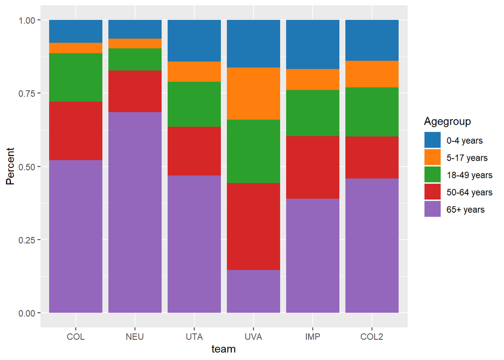

```r
#Bar chart for ages
ages <- read_ages(scn = scenario)
ggplot(ages, aes(fill=Agegroup, y=Cml, x=team)) +
  geom_bar(position="fill", stat="identity") +
  ylab("Percent")+
  scale_fill_d3()
```

```r
averted <- rbind(averted, data.frame(scenario = rep(scenario, nrow(table)),
                                     team = table$Team,
                                     reduction = table$`% Reduction in Burden (HP01)`))
averted_age <- rbind(averted_age,
                     data.frame(scenario = scenario,
                          team = ages$team[which(ages$Bin == "sm.mean")],
                          agegroup = ages$Agegroup[which(ages$Bin == "sm.mean")],
                          reduction = 100*(ages_1$Cml[which(ages_1$Bin == "sm.mean")] -
                                       ages$Cml[which(ages$Bin == "sm.mean")]) /
                            ages_1$Cml[which(ages_1$Bin == "sm.mean")]))
```

### HP10

VX1 & SC2 & AV

- “Early”: Vaccine available 100 days after September 1
- Close on October 28, early (VX1) vaccine availability reopening
- Antivirals

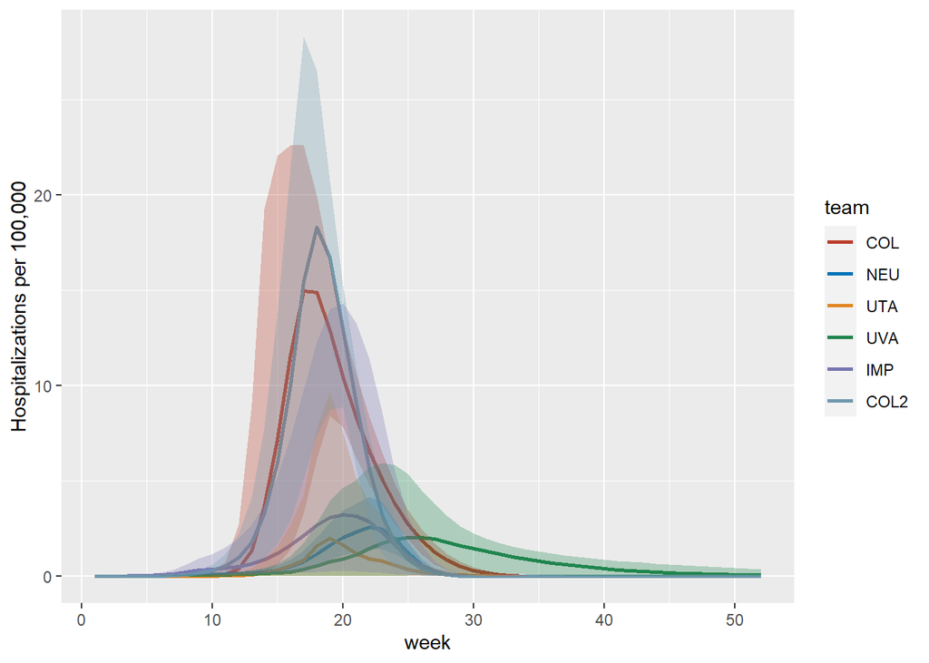

```r
scenario <- "HP10_"

long <- read_overall_mean(scn = scenario)

ggplot(data = long, aes(x = week, y = sm.mean, group = team)) +
  geom_line(aes(color = team), lwd = 1.0) +
  geom_ribbon(aes(ymin = sm.perc2p5, ymax = sm.perc97p5, fill = team), alpha = 0.3,
              show.legend = FALSE)+
  ylab("Hospitalizations per 100,000") +
  scale_color_nejm() +
  scale_fill_nejm()
```

```r
table <- cml[which(cml$Bin == "sm.mean"),]
table <- table[,-3]

table$lower <-  cml$Cml[which(cml$Bin == "sm.perc2p5")]
table$upper <-  cml$Cml[which(cml$Bin == "sm.perc97p5")]
table$Team <- table$team
table$`Cum. Hospitalizations per 100K` <- table$Cml
table$`95% CI` <- paste0("(", round(table$lower, 2), ", ", round(table$upper, 2), ")")

table$`Averted Hospitalizations per 100K (HP01)` <- ifelse(table$Team %in% table1$Team, table1$`Cum. Hospitalizations per 100K` - table$`Cum. Hospitalizations per 100K`, NA)
table$`% Reduction in Burden (HP01)` <- ifelse(table$Team %in% table1$Team, 100 * (table1$`Cum. Hospitalizations per 100K` - table$`Cum. Hospitalizations per 100K`) / table1$`Cum. Hospitalizations per 100K`, NA)

rownames(table) <- NULL

knitr::kable(table[5:9], digits = 2, caption = "HP10: Compared to HP01", align=rep('c', 4)) %>%
  kable_styling(bootstrap_options = c("striped", "hover"))
```

HP10: Compared to HP01

| Team | Cum. Hospitalizations per 100K | 95% CI | Averted Hospitalizations per 100K (HP01) | % Reduction in Burden (HP01) |
| --- | --- | --- | --- | --- |
| COL | 109.33 | (57.08, 172.36) | 91.58 | 45.58 |
| NEU | 19.17 | (15.55, 30.54) | 326.31 | 94.45 |
| UTA | 12.03 | (0.02, 53.3) | 392.27 | 97.03 |
| UVA | 31.18 | (6.9, 58.91) | 104.34 | 76.99 |
| IMP | 29.89 | (3.2, 120.94) | 433.56 | 93.55 |
| COL2 | 107.76 | (63.38, 146.76) | 114.82 | 51.59 |

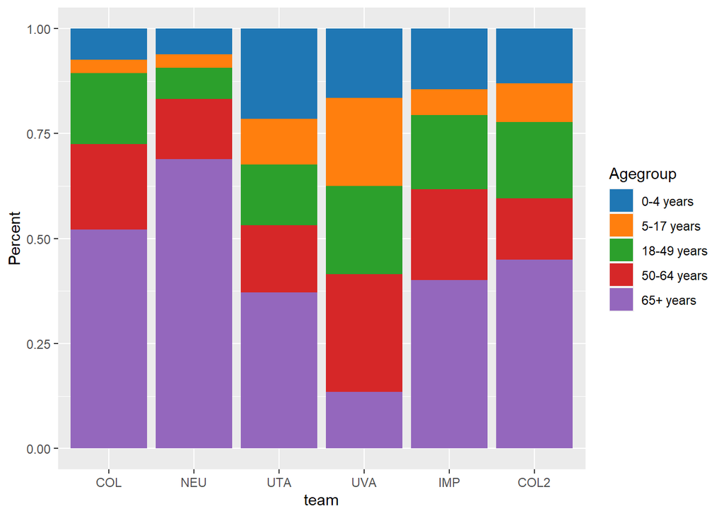

```r
#Bar chart for ages
ages <- read_ages(scn = scenario)
ggplot(ages, aes(fill=Agegroup, y=Cml, x=team)) +
  geom_bar(position="fill", stat="identity") +
  ylab("Percent")+
  scale_fill_d3()
```

```r
averted <- rbind(averted, data.frame(scenario = rep(scenario, nrow(table)),
                                     team = table$Team,
                                     reduction = table$`% Reduction in Burden (HP01)`))
averted_age <- rbind(averted_age,
                     data.frame(scenario = scenario,
                          team = ages$team[which(ages$Bin == "sm.mean")],
                          agegroup = ages$Agegroup[which(ages$Bin == "sm.mean")],
                          reduction = 100*(ages_1$Cml[which(ages_1$Bin == "sm.mean")] -
                                       ages$Cml[which(ages$Bin == "sm.mean")]) /
                            ages_1$Cml[which(ages_1$Bin == "sm.mean")]))
```

### HP11

VX2 & SC3 & AV

- “Normal”: Vaccine available 150 days after September 1
- Weekly Symptomatic Prevalence > 1% trigger, normal (VX2) vaccine availability reopening
- Antivirals

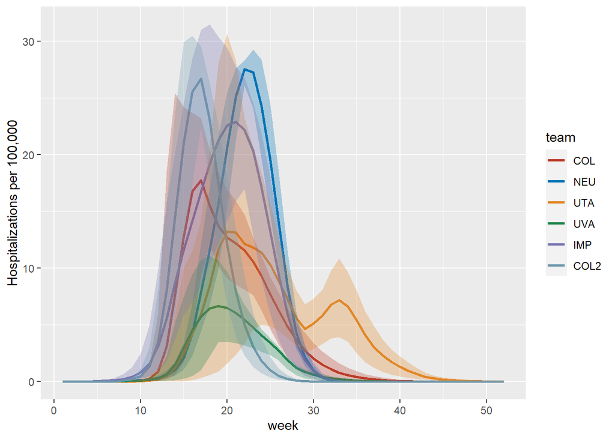

```r
scenario <- "HP11_"

long <- read_overall_mean(scn = scenario)

ggplot(data = long, aes(x = week, y = sm.mean, group = team)) +
  geom_line(aes(color = team), lwd = 1.0) +
  geom_ribbon(aes(ymin = sm.perc2p5, ymax = sm.perc97p5, fill = team), alpha = 0.3,
              show.legend = FALSE)+
  ylab("Hospitalizations per 100,000") +
  scale_color_nejm() +
  scale_fill_nejm()
```

```r
table <- cml[which(cml$Bin == "sm.mean"),]
table <- table[,-3]

table$lower <-  cml$Cml[which(cml$Bin == "sm.perc2p5")]
table$upper <-  cml$Cml[which(cml$Bin == "sm.perc97p5")]
table$Team <- table$team
table$`Cum. Hospitalizations per 100K` <- table$Cml
table$`95% CI` <- paste0("(", round(table$lower, 2), ", ", round(table$upper, 2), ")")

table$`Averted Hospitalizations per 100K (HP01)` <- ifelse(table$Team %in% table1$Team, table1$`Cum. Hospitalizations per 100K` - table$`Cum. Hospitalizations per 100K`, NA)
table$`% Reduction in Burden (HP01)` <- ifelse(table$Team %in% table1$Team, 100 * (table1$`Cum. Hospitalizations per 100K` - table$`Cum. Hospitalizations per 100K`) / table1$`Cum. Hospitalizations per 100K`, NA)

rownames(table) <- NULL

knitr::kable(table[5:9], digits = 2, caption = "HP11: Compared to HP01", align=rep('c', 4)) %>%
  kable_styling(bootstrap_options = c("striped", "hover"))
```

HP11: Compared to HP01

| Team | Cum. Hospitalizations per 100K | 95% CI | Averted Hospitalizations per 100K (HP01) | % Reduction in Burden (HP01) |
| --- | --- | --- | --- | --- |
| COL | 177.47 | (127.51, 232.43) | 23.44 | 11.67 |
| NEU | 218.84 | (216.83, 224.6) | 126.65 | 36.66 |
| UTA | 185.84 | (79.53, 287.72) | 218.45 | 54.03 |
| UVA | 68.51 | (35.15, 99.59) | 67.01 | 49.45 |
| IMP | 244.32 | (181.66, 302.73) | 219.12 | 47.28 |
| COL2 | 173.89 | (160.53, 186.51) | 48.69 | 21.88 |

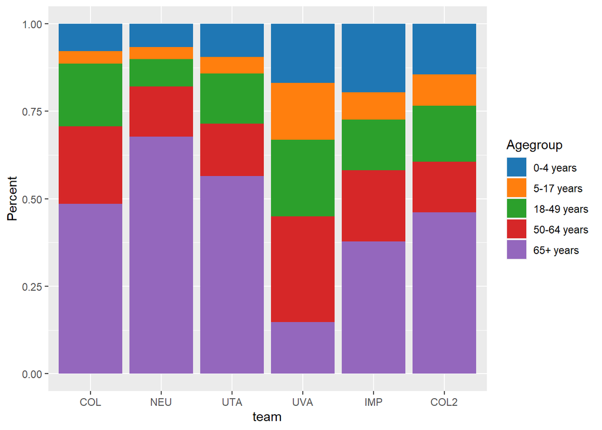

```r
#Bar chart for ages
ages <- read_ages(scn = scenario)
ggplot(ages, aes(fill=Agegroup, y=Cml, x=team)) +
  geom_bar(position="fill", stat="identity") +
  ylab("Percent")+
  scale_fill_d3()
```

```r
averted <- rbind(averted, data.frame(scenario = rep(scenario, nrow(table)),
                                     team = table$Team,
                                     reduction = table$`% Reduction in Burden (HP01)`))
averted_age <- rbind(averted_age,
                     data.frame(scenario = scenario,
                          team = ages$team[which(ages$Bin == "sm.mean")],
                          agegroup = ages$Agegroup[which(ages$Bin == "sm.mean")],
                          reduction = 100*(ages_1$Cml[which(ages_1$Bin == "sm.mean")] -
                                       ages$Cml[which(ages$Bin == "sm.mean")]) /
                            ages_1$Cml[which(ages_1$Bin == "sm.mean")]))
```

### HP12

VX2 & SC4 & AV

- “Normal”: Vaccine available 150 days after September 1
- Close on October 28, normal (VX2) vaccine availability reopening
- Antivirals

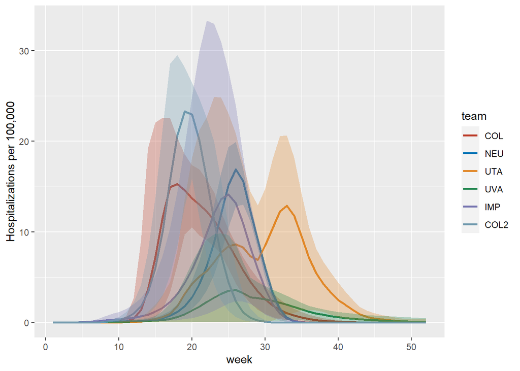

```r
scenario <- "HP12_"

long <- read_overall_mean(scn = scenario)

ggplot(data = long, aes(x = week, y = sm.mean, group = team)) +
  geom_line(aes(color = team), lwd = 1.0) +
  geom_ribbon(aes(ymin = sm.perc2p5, ymax = sm.perc97p5, fill = team), alpha = 0.3,
              show.legend = FALSE)+
  ylab("Hospitalizations per 100,000") +
  scale_color_nejm() +
  scale_fill_nejm()
```

```r
table <- cml[which(cml$Bin == "sm.mean"),]
table <- table[,-3]

table$lower <-  cml$Cml[which(cml$Bin == "sm.perc2p5")]
table$upper <-  cml$Cml[which(cml$Bin == "sm.perc97p5")]
table$Team <- table$team
table$`Cum. Hospitalizations per 100K` <- table$Cml
table$`95% CI` <- paste0("(", round(table$lower, 2), ", ", round(table$upper, 2), ")")

table$`Averted Hospitalizations per 100K (HP01)` <- ifelse(table$Team %in% table1$Team, table1$`Cum. Hospitalizations per 100K` - table$`Cum. Hospitalizations per 100K`, NA)
table$`% Reduction in Burden (HP01)` <- ifelse(table$Team %in% table1$Team, 100 * (table1$`Cum. Hospitalizations per 100K` - table$`Cum. Hospitalizations per 100K`) / table1$`Cum. Hospitalizations per 100K`, NA)

rownames(table) <- NULL

knitr::kable(table[5:9], digits = 2, caption = "HP12: Compared to HP01", align=rep('c', 4)) %>%
  kable_styling(bootstrap_options = c("striped", "hover"))
```

HP12: Compared to HP01

| Team | Cum. Hospitalizations per 100K | 95% CI | Averted Hospitalizations per 100K (HP01) | % Reduction in Burden (HP01) |
| --- | --- | --- | --- | --- |
| COL | 168.79 | (118.35, 223.59) | 32.12 | 15.99 |
| NEU | 120.23 | (111.4, 144.85) | 225.25 | 65.20 |
| UTA | 171.02 | (17.11, 290.31) | 233.28 | 57.70 |
| UVA | 50.17 | (8.26, 98.35) | 85.34 | 62.98 |
| IMP | 125.48 | (21.04, 281.54) | 337.97 | 72.92 |
| COL2 | 169.32 | (151.58, 184.93) | 53.26 | 23.93 |

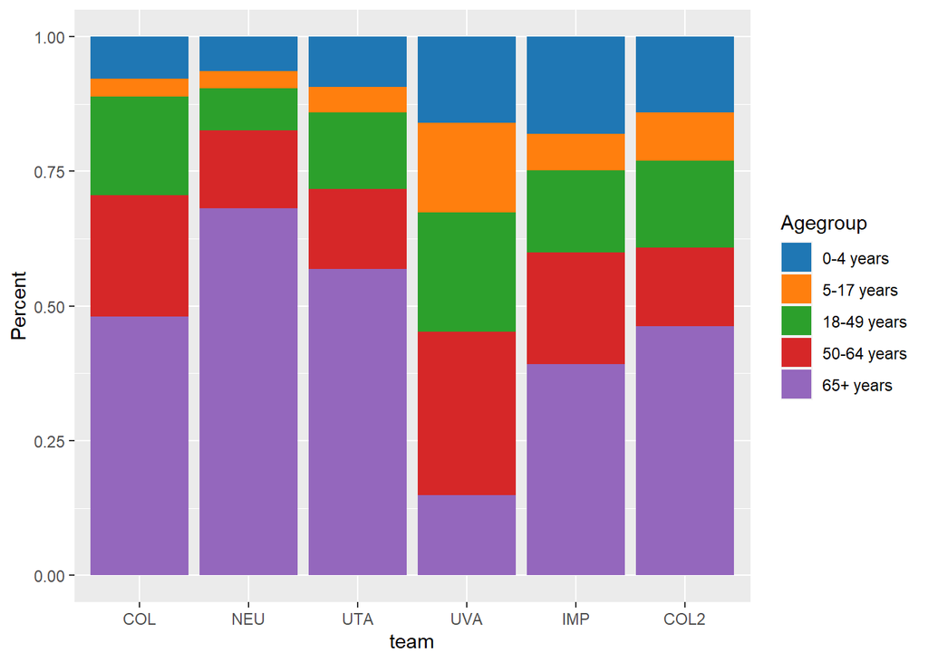

```r
#Bar chart for ages
ages <- read_ages(scn = scenario)
ggplot(ages, aes(fill=Agegroup, y=Cml, x=team)) +
  geom_bar(position="fill", stat="identity") +
  ylab("Percent")+
  scale_fill_d3()
```

```r
averted <- rbind(averted, data.frame(scenario = rep(scenario, nrow(table)),
                                     team = table$Team,
                                     reduction = table$`% Reduction in Burden (HP01)`))
averted_age <- rbind(averted_age,
                     data.frame(scenario = scenario,
                          team = ages$team[which(ages$Bin == "sm.mean")],
                          agegroup = ages$Agegroup[which(ages$Bin == "sm.mean")],
                          reduction = 100*(ages_1$Cml[which(ages_1$Bin == "sm.mean")] -
                                       ages$Cml[which(ages$Bin == "sm.mean")]) /
                            ages_1$Cml[which(ages_1$Bin == "sm.mean")]))
write.csv(averted, "Hospitalizations_EPI1.csv")
write.csv(averted_age, "Hospitalizations_age_EPI1.csv")
```